# Trabajo académico

Álvaro Trives Hernandis, Pablo Aleixandre Moreno, Pablo Ortiz Badenes y Rubén García Villoldo

Curso 2026/2027

## Importación de datos y descripción de variables

Se importan los datos y se clasifican las variables según su tipo para aplicar en cada caso los resúmenes y gráficos adecuados.

## Limpieza inicial de la BBDD

Se revisaron la variabilidad y las distribuciones de las variables para detectar variables prácticamente constantes y valores atípicos.

No se detectaron variables numéricas constantes. De entre las variables categóricas, se eliminó `Educational.special.needs` porque solo una observación presenta el valor 1, por lo que se considera prácticamente constante y no permitiría obtener conclusiones fiables.

Los diagramas exploratorios muestran valores atípicos en las variables numéricas. No obstante, se conservan por que la existencia de datos atípicos no justifica directamente su eliminación o interpolación.

`Application.order` y `Previous.qualification` presentan distribuciones muy desiguales. No obstante, se mantienen porque son necesarias para responder a preguntas posteriores de la práctica.

## Práctica 1

### a)

**En ocasiones, es necesario o recomendable que ciertas variables sigan una distribución aproximadamente normal o, al menos, simétrica. En este sentido, ¿se puede asumir la normalidad de la variable Admission.grade? En caso negativo, si es posible, proponed una transformación para conseguir la normalidad.**

Se representa primero la variable, así como su logaritmo, para observar en primer lugar de manera cualitativa si su distribución se asemeja a la normal. No obstante, aún antes de realizar la representación, se puede suponer que no lo será, pues las notas de admisión son no negativas, mientras que la distribución normal toma valores en toda la recta real.

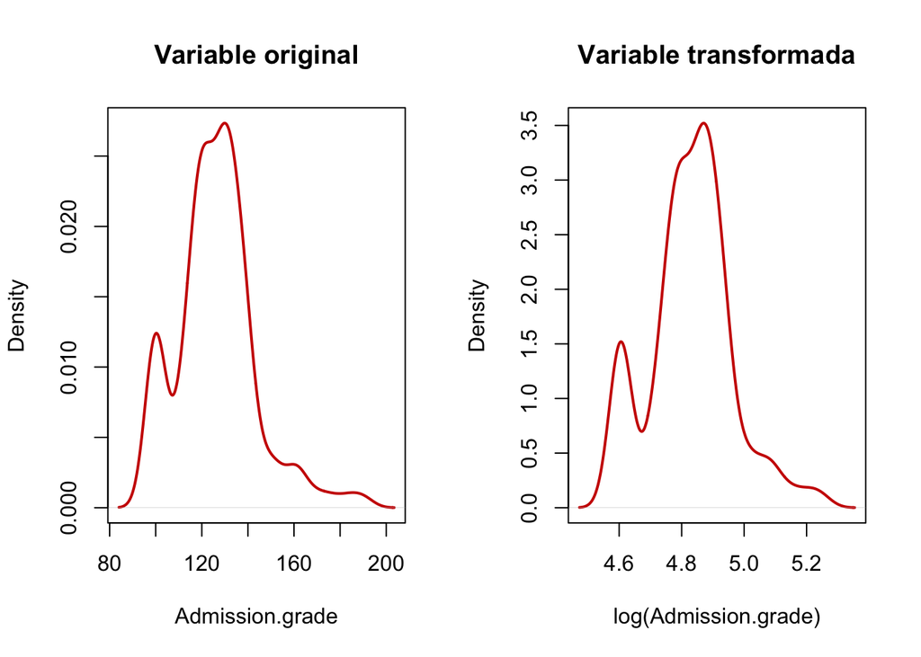

```r
par(mfrow = c(1,2))
plot(density(datos$Admission.grade), main = "Variable original", col = "red3",
     lwd = 2, xlab = "Admission.grade")

plot(density(log(datos$Admission.grade)), main = "Variable transformada",
     col = "red3", lwd = 2, xlab = "log(Admission.grade)")
```

Efectivamente, la variable Admission.grade no sigue una distribución normal, y su transformación logarítmica tampoco. Por tanto, no se puede asumir la normalidad de la variable Admission.grade. Puesto que en ocasiones es necesario que una variable se aproxime a una distribución normal, se prueba con una transformación box-cox.

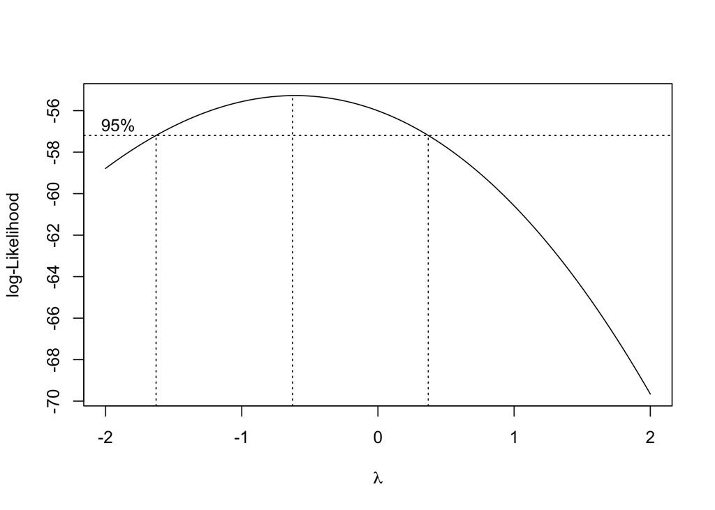

```r
library(MASS)
x <- datos$Admission.grade
b <- boxcox(lm(x ~ 1))
```

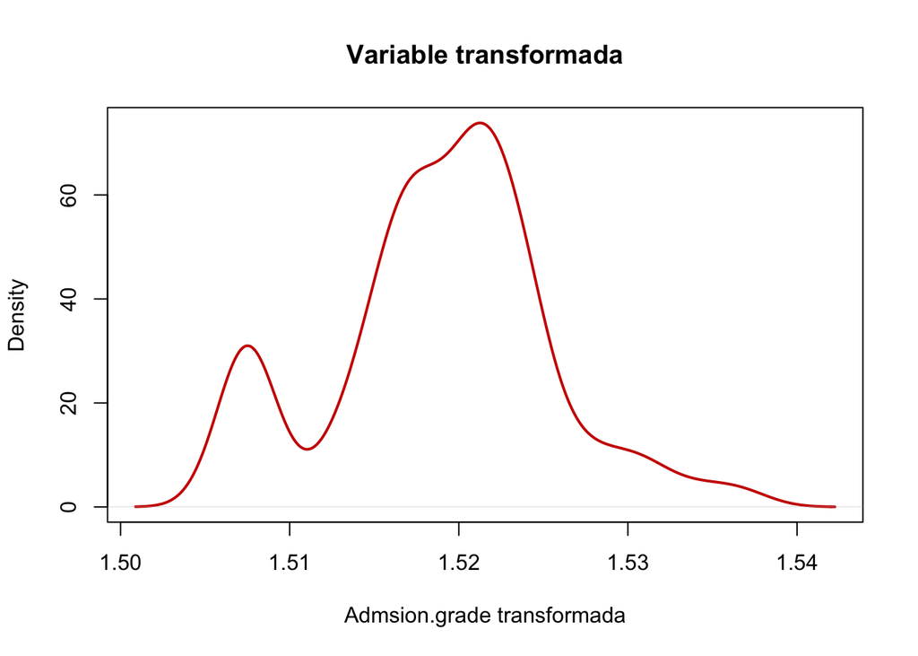

```r
# Lambda exacto
lambda <- b$x[which.max(b$y)]

# Transformacion
new_x <- (x ^ lambda - 1) / lambda

plot(density(new_x), main = "Variable transformada", col = "red3", lwd = 2,
     xlab = "Admsion.grade transformada")
```

Si bien es cierto que la asimetría queda más corregida, y la distribución se aproxima más a una normal que la original, no se puede asumir que la variable transformada siga una distribución normal, puesto que se puede apreciar cualitativamente la diferencia.

### b)

**Proporcionad un resumen descriptivo para las variables Previous.qualification..grade. y Application.order, utilizando las herramientas gráficas y/o numéricas que consideréis más adecuadas en función de la naturaleza de cada variable.**

En el caso de Previous.qualification..grade, se trata de una variable numérica, por lo que se puede representar mediante un histograma y un diagrama de caja y bigotes, así como calcular medidas de tendencia central y dispersión. En cambio, la variable Application.order es categórica ordinal, por lo que se puede representar mediante un gráfico de barras y calcular medidas de tendencia central y dispersión apropiadas para este tipo de variable.

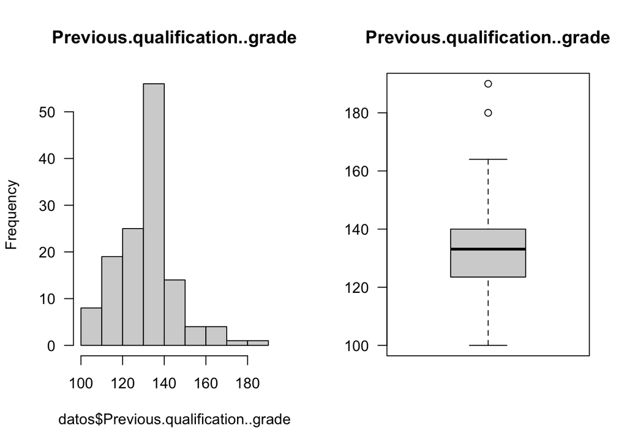

```r
par(mfrow = c(1, 2))
hist(datos$Previous.qualification..grade, las = 1,
     main = "Previous.qualification..grade")

boxplot(datos$Previous.qualification..grade, las = 1,
        main = "Previous.qualification..grade")
```

```r
avg_grade <- mean(datos$Previous.qualification..grade, na.rm = TRUE)
sd_grade <- sd(datos$Previous.qualification..grade, na.rm = TRUE)

avg_grade
```

```
## [1] 132.7742
```

```r
sd_grade
```

```
## [1] 14.66561
```

La media obtenida es de 132.7742 y una desviación típica de 14.66561, lo que indica que la variable Previous.qualification..grade tiene una distribución bastante concentrada alrededor de su media, con pocos valores extremos.

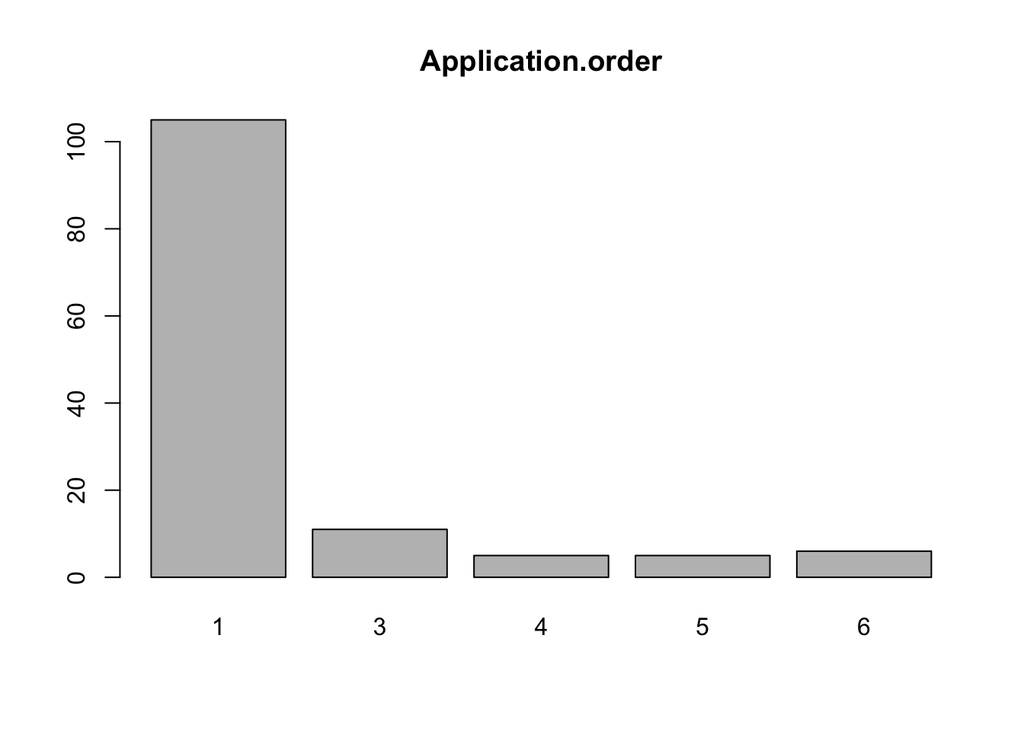

```r
barplot(table(datos$Application.order), main = "Application.order")
```

```r
avg_order <- mean(as.numeric(datos$Application.order), na.rm = TRUE)
sd_order <- sd(as.numeric(datos$Application.order), na.rm = TRUE)
cv_order <- (sd_order / avg_order) * 100

median_order <- median(datos$Application.order, na.rm = TRUE)
moda_order <- as.numeric(names(sort(table(datos$Application.order),
                                    decreasing = TRUE))[1])

# --- Coeficiente de asimetría (sesgo de Fisher) ---
n <- length(datos$Application.order)
m3 <- sum((datos$Application.order - avg_order)^3, na.rm = TRUE) /
  length(datos$Application.order)
asym_order <- m3 / sd_order^3

avg_order
```

```
## [1] 1.659091
```

```r
sd_order
```

```
## [1] 1.413293
```

```r
cv_order
```

```
## [1] 85.1848
```

```r
median_order
```

```
## [1] 1
```

```r
moda_order
```

```
## [1] 1
```

```r
asym_order
```

```
## [1] 1.980108
```

Por otra parte, la variable Application.order tiene una media de 1.659091 y una desviación típica de 1.413293. No obstante, tanto la mediana como la moda son de 1, el coeficiente de variación es del 85%, y el coeficiente de asimetría de 1.98, lo que indica que la dispersión es alta, y hay una pronunciada asimetría, con una cola hacia la derecha.

## Práctica 2

### a)

```r
shapiro.test(datos$Admission.grade)
```

```
##
##  Shapiro-Wilk normality test
##
## data:  datos$Admission.grade
## W = 0.93545, p-value = 8.75e-06
```

Como el p-valor es tan pequeño, existe evidencia muestral para rechazar la hipótesis de normalidad de nuestros datos.

Como hemos visto, los datos no siguen una distribución normal. Por tanto,procedemos mediante un contraste de hipótesis asintótico ya que contamos con una muestra suficientemente grande (n=132).

```r
Htest <- t.test(datos$Admission.grade, alternative = "two.sided", mu = 125.2,
                conf.level = 0.99)
Htest
```

```
##
##  One Sample t-test
##
## data:  datos$Admission.grade
## t = 0.75019, df = 131, p-value = 0.4545
## alternative hypothesis: true mean is not equal to 125.2
## 99 percent confidence interval:
##  122.3920 130.2686
## sample estimates:
## mean of x
##  126.3303
```

Por tanto, como el p-valor es mayor que nuestro nivel de significación no tenemos suficiente evidencia estadística para rechazar la hipótesis nula con un nivel de significación de 0.01, luego sí que es admisible una media de 125.2.

```r
Htest$conf.int
```

```
## [1] 122.3920 130.2686
## attr(,"conf.level")
## [1] 0.99
```

El intervalo del confianza al 99% se encuentra entre 122.39 y 130.27. Así, 125.2 se encuentra en este intervalo con un 99% de confianza.

### b)

Como ahora asumimos normalidad en los datos podemos realizar un contraste de hipótesis bilateral para población normal como sigue:

```r
Vtest <- varTest(datos$Admission.grade, alternative = "two.sided",
                 conf.level = 0.99, sigma.squared = 595.3646)
Vtest
```

```
## $statistic
## Chi-Squared
##    65.93344
##
## $parameters
##  df
## 131
##
## $p.value
## [1] 7.657265e-07
##
## $estimate
## variance
## 299.6522
##
## $null.value
## variance
## 595.3646
##
## $alternative
## [1] "two.sided"
##
## $method
## [1] "Chi-Squared Test on Variance"
##
## $data.name
## [1] "datos$Admission.grade"
##
## $conf.int
##      LCL      UCL
## 222.4831 421.8048
## attr(,"conf.level")
## [1] 0.99
##
## attr(,"class")
## [1] "htestEnvStats"
```

En este caso, el p-valor es mucho menor que nuestro nivel de significación, por lo que podemos concluir que existe suficiente evidencia muestral para rechazar la propuesta de varianza igual a 595.3646 con un nivel de significación de 0.01. Así, podemos afirmar que la variable Admission.grade tiene una varianza distinta a 595.3646.

### c)

Para la resolución de este apartado, planteamos $H_{0}: p_{A} \leq 0.25$ frente a $H_{1}:p_{A} > 0.25$ siendo $p_{A}=P(Admission.grade>130.46)$ y vemos que

```r
n <- length(datos$Admission.grade)
p_0 <- 0.25
prop_muestral <- sum(datos$Admission.grade > 130.46) / n

#Estadistico del contraste
Z0 <- (prop_muestral - p_0)/sqrt((p_0 * (1 - p_0)) / n)
Z0
```

```
## [1] 3.015113
```

```r
pnorm(q = Z0, lower.tail = FALSE)
```

```
## [1] 0.001284416
```

Como el p-valor obtenido es significativamente menor al nivel de significación, $\alpha = 1\%$ , existe suficiente evidencia muestral para rechazar la hipótesis $H_{0}$ , es decir, la proporción de estudiantes con una nota de admisión superior a $130.46$ es superior al 25%.

Si quisiésemos hacerlo de forma exacta, emplearíamos directamente la distribución binomial del estadístico proporción muestral.

```r
binom.test(x = sum(datos$Admission.grade>130.46),n,p = p_0,
           alternative = "greater", conf.level = 0.99)
```

```
##
##  Exact binomial test
##
## data:  sum(datos$Admission.grade > 130.46) and n
## number of successes = 48, number of trials = 132, p-value = 0.002447
## alternative hypothesis: true probability of success is greater than 0.25
## 99 percent confidence interval:
##  0.2678988 1.0000000
## sample estimates:
## probability of success
##              0.3636364
```

Finalmente, calculamos el intervalo de confianza

```r
Ptest_exacto <- binom.test(x = sum(datos$Admission.grade>130.46), n,
                           alternative = "greater", p = p_0, conf.level = 0.99)
Ptest_exacto$conf.int
```

```
## [1] 0.2678988 1.0000000
## attr(,"conf.level")
## [1] 0.99
```

Como el intervalo de confianza para $\alpha=0.01$, es $[0.2678988,1]$, se puede afirmar con un 99% de confianza que la proporción de estudiantes con una nota de admisión superior a $130.46$ es superior al 25%.